# R_solo

```r
library(tidyverse)
library(ggplot2)
```

##Q1.Read in districts.csv into a tibble named districts. How many rows and columns does it contain? #146 rows and 27 columns

```r
districts <- read.csv('./data/districts.csv')
glimpse(districts)
```

```
Rows: 146
Columns: 27
$ system        <int> 0, 10, 11, 12, 20, 30, 40, 50, 51, 52, 60, 61, 70, 80, 92, 93, …
$ system_name   <chr> "State of Tennessee", "Anderson County", "Clinton City", "Oak R…
$ alg_1         <dbl> 70.0, 76.1, NA, 76.9, 64.3, 73.7, 64.8, 73.2, 82.2, 83.8, NA, 6…
$ alg_2         <dbl> 54.3, 63.3, NA, 72.0, 42.4, 58.4, 73.9, 59.8, 76.8, 77.3, 59.5,…
$ bio           <dbl> 65.3, 73.6, NA, 83.5, 62.1, 77.1, 73.0, 65.1, 88.0, 92.1, 64.1,…
$ chem          <dbl> 44.2, 41.0, NA, 80.9, 32.5, 33.1, 19.5, 45.4, 66.0, 80.4, 55.7,…
$ ela           <dbl> 48.4, 45.7, 58.3, 56.1, 44.1, 46.0, 35.4, 46.3, 50.2, 69.6, 52.…
$ eng_1         <dbl> 71.8, 73.7, NA, 86.7, 72.3, 75.4, 63.6, 71.8, 85.5, 89.9, 74.4,…
$ eng_2         <dbl> 64.8, 59.2, NA, 74.6, 63.1, 60.8, 53.3, 66.0, 79.6, 82.7, 66.3,…
$ eng_3         <dbl> 41.7, 38.2, NA, 53.8, 44.6, 45.6, 50.0, 45.3, 67.2, 68.1, 38.2,…
$ math          <dbl> 54.7, 54.0, 68.9, 55.3, 53.1, 53.9, 41.1, 50.5, 56.6, 70.2, 57.…
$ science       <dbl> 64.5, 64.5, 69.6, 70.8, 61.8, 65.0, 56.2, 68.4, 65.1, 87.1, 65.…
$ enrollment    <int> 943699, 6304, 894, 4326, 8270, 2133, 1674, 10500, 1850, 4944, 9…
$ black         <dbl> 24.1, 2.8, 5.7, 16.6, 11.2, 3.9, 1.5, 3.0, 23.3, 4.2, 3.6, 15.0…
$ hispanic      <dbl> 8.5, 1.1, 2.8, 8.0, 20.6, 2.1, 6.8, 4.2, 9.5, 4.0, 4.3, 18.8, 1…
$ native        <dbl> 0.3, 0.5, 0.3, 0.7, 0.5, 0.3, 0.6, 0.4, 0.6, 0.2, 0.3, 0.3, 0.2…
$ el            <dbl> 4.6, 0.2, 1.0, 3.0, 9.4, 0.0, 2.3, 1.9, 2.7, 2.8, 1.6, 8.2, 0.6…
$ swd           <dbl> 14.0, 18.0, 18.1, 14.3, 10.9, 18.8, 19.7, 12.8, 13.0, 13.2, 11.…
$ ed            <dbl> 57.9, 58.5, 63.4, 52.5, 69.9, 50.2, 83.5, 54.2, 49.4, 32.1, 55.…
$ expenditures  <dbl> 9374.9, 9535.7, 9537.5, 12355.5, 7756.2, 9714.2, 9495.9, 8866.9…
$ act_composite <dbl> 19.4, 19.9, NA, 23.1, 18.4, 18.4, 19.2, 19.7, 22.0, 23.0, 18.8,…
$ chronic_abs   <dbl> 13.2, 11.5, 8.8, 17.5, 8.6, 6.5, 9.1, 17.0, 4.7, 2.0, 16.0, 15.…
$ suspended     <dbl> 6.2, 5.0, 1.2, 5.7, 2.2, 0.0, 2.4, 4.7, 3.1, 2.7, 3.9, 7.0, 4.6…
$ expelled      <dbl> 0.2, 0.1, 0.0, 0.0, 0.0, 0.0, 0.1, 0.1, 0.1, 0.0, 0.1, 0.0, 0.0…
$ grad          <dbl> 87.2, 94.0, NA, 89.7, 90.8, 94.5, 92.4, 89.1, 98.2, 96.6, 93.1,…
$ dropout       <dbl> 8.4, 4.2, NA, 4.4, 5.4, 3.0, 6.9, 9.2, 0.9, 3.1, 5.6, 12.3, 3.1…
$ region        <chr> "", "East TN", "East TN", "East TN", "South Central", "Northwes…
```

#Gives us the first few rows.

```r
head(districts)
```

[output not shown]

#Open the dataset in data viewer section

```r
view (districts)
```

#Structure of the dataframe

```r
str(distrcits)
```

[output not shown]

##Q2. Notice that the first row corresponds to the whole State of Tennessee. Remove this row and save the result back to districts.

```r
districts <- districts %>%
  slice(-(1))
```

```r
districts
```

| system | system_name | alg_1 | alg_2 | bio | chem | ela | eng_1 | eng_2 | eng_3 | math | science | enrollment | black | hispanic | native | el | swd | ed | expenditures | act_composite | chronic_abs | suspended | expelled | grad | dropout | region |
| --- | --- | --- | --- | --- | --- | --- | --- | --- | --- | --- | --- | --- | --- | --- | --- | --- | --- | --- | --- | --- | --- | --- | --- | --- | --- | --- |
| 10 | Anderson County | 76.1 | 63.3 | 73.6 | 41.0 | 45.7 | 73.7 | 59.2 | 38.2 | 54.0 | 64.5 | 6304 | 2.8 | 1.1 | 0.5 | 0.2 | 18.0 | 58.5 | 9535.7 | 19.9 | 11.5 | 5.0 | 0.1 | 94.0 | 4.2 | East TN |
| 11 | Clinton City | NA | NA | NA | NA | 58.3 | NA | NA | NA | 68.9 | 69.6 | 894 | 5.7 | 2.8 | 0.3 | 1.0 | 18.1 | 63.4 | 9537.5 | NA | 8.8 | 1.2 | 0.0 | NA | NA | East TN |
| 12 | Oak Ridge City | 76.9 | 72.0 | 83.5 | 80.9 | 56.1 | 86.7 | 74.6 | 53.8 | 55.3 | 70.8 | 4326 | 16.6 | 8.0 | 0.7 | 3.0 | 14.3 | 52.5 | 12355.5 | 23.1 | 17.5 | 5.7 | 0.0 | 89.7 | 4.4 | East TN |
| 20 | Bedford County | 64.3 | 42.4 | 62.1 | 32.5 | 44.1 | 72.3 | 63.1 | 44.6 | 53.1 | 61.8 | 8270 | 11.2 | 20.6 | 0.5 | 9.4 | 10.9 | 69.9 | 7756.2 | 18.4 | 8.6 | 2.2 | 0.0 | 90.8 | 5.4 | South Central |
| 30 | Benton County | 73.7 | 58.4 | 77.1 | 33.1 | 46.0 | 75.4 | 60.8 | 45.6 | 53.9 | 65.0 | 2133 | 3.9 | 2.1 | 0.3 | 0.0 | 18.8 | 50.2 | 9714.2 | 18.4 | 6.5 | 0.0 | 0.0 | 94.5 | 3.0 | Northwest |
| 40 | Bledsoe County | 64.8 | 73.9 | 73.0 | 19.5 | 35.4 | 63.6 | 53.3 | 50.0 | 41.1 | 56.2 | 1674 | 1.5 | 6.8 | 0.6 | 2.3 | 19.7 | 83.5 | 9495.9 | 19.2 | 9.1 | 2.4 | 0.1 | 92.4 | 6.9 | Upper Cumberland |
| 50 | Blount County | 73.2 | 59.8 | 65.1 | 45.4 | 46.3 | 71.8 | 66.0 | 45.3 | 50.5 | 68.4 | 10500 | 3.0 | 4.2 | 0.4 | 1.9 | 12.8 | 54.2 | 8866.9 | 19.7 | 17.0 | 4.7 | 0.1 | 89.1 | 9.2 | East TN |
| 51 | Alcoa City | 82.2 | 76.8 | 88.0 | 66.0 | 50.2 | 85.5 | 79.6 | 67.2 | 56.6 | 65.1 | 1850 | 23.3 | 9.5 | 0.6 | 2.7 | 13.0 | 49.4 | 10320.0 | 22.0 | 4.7 | 3.1 | 0.1 | 98.2 | 0.9 | East TN |
| 52 | Maryville City | 83.8 | 77.3 | 92.1 | 80.4 | 69.6 | 89.9 | 82.7 | 68.1 | 70.2 | 87.1 | 4944 | 4.2 | 4.0 | 0.2 | 2.8 | 13.2 | 32.1 | 10161.2 | 23.0 | 2.0 | 2.7 | 0.0 | 96.6 | 3.1 | East TN |
| 60 | Bradley County | NA | 59.5 | 64.1 | 55.7 | 52.4 | 74.4 | 66.3 | 38.2 | 57.1 | 65.9 | 9801 | 3.6 | 4.3 | 0.3 | 1.6 | 11.3 | 55.1 | 8429.3 | 18.8 | 16.0 | 3.9 | 0.1 | 93.1 | 5.6 | Southeast |

[output cut: 135 more lines]

##Q3. How many districts have a proficiency rate of at least 80% for both alg_1 and eng_1? #13 districts

```r
  filter (districts, alg_1 >= 80 & eng_1 >= 80) %>%
  count()
```

| n |
| --- |
| 13 |

#what are the districts?

```r
 filter (districts, alg_1 >= 80 & eng_1 >= 80)
```

| system | system_name | alg_1 | alg_2 | bio | chem | ela | eng_1 | eng_2 | eng_3 | math | science | enrollment | black | hispanic | native | el | swd | ed | expenditures | act_composite | chronic_abs | suspended | expelled | grad | dropout | region |
| --- | --- | --- | --- | --- | --- | --- | --- | --- | --- | --- | --- | --- | --- | --- | --- | --- | --- | --- | --- | --- | --- | --- | --- | --- | --- | --- |
| 51 | Alcoa City | 82.2 | 76.8 | 88.0 | 66.0 | 50.2 | 85.5 | 79.6 | 67.2 | 56.6 | 65.1 | 1850 | 23.3 | 9.5 | 0.6 | 2.7 | 13.0 | 49.4 | 10320.0 | 22.0 | 4.7 | 3.1 | 0.1 | 98.2 | 0.9 | East TN |
| 52 | Maryville City | 83.8 | 77.3 | 92.1 | 80.4 | 69.6 | 89.9 | 82.7 | 68.1 | 70.2 | 87.1 | 4944 | 4.2 | 4.0 | 0.2 | 2.8 | 13.2 | 32.1 | 10161.2 | 23.0 | 2.0 | 2.7 | 0.0 | 96.6 | 3.1 | East TN |
| 273 | Trenton SSD | 91.6 | 84.7 | 75.6 | 64.5 | 44.6 | 82.6 | 76.0 | 50.6 | 62.9 | 53.6 | 1278 | 28.2 | 6.0 | 0.0 | 0.1 | 12.7 | 66.1 | 8916.6 | 18.6 | 10.5 | 2.8 | 0.0 | 83.5 | 11.0 | Northwest |
| 274 | Bradford SSD | 94.4 | 92.6 | 87.9 | 66.7 | 56.5 | 81.8 | 68.4 | 70.4 | 73.4 | 75.4 | 499 | 6.1 | 0.6 | 0.0 | 0.0 | 17.3 | 62.8 | 10143.5 | 18.7 | 11.4 | 0.9 | 0.0 | 100.0 | 0.0 | Northwest |
| 275 | Gibson County SSD | 83.7 | 73.2 | 75.3 | 63.0 | 57.8 | 83.8 | 73.5 | 59.6 | 67.5 | 79.7 | 3832 | 7.8 | 2.0 | 0.0 | 0.4 | 13.3 | 42.3 | 7270.0 | 19.7 | 8.2 | 0.0 | 0.0 | 94.9 | 4.0 | Northwest |
| 301 | Greeneville City | 83.2 | 90.2 | 77.7 | 86.1 | 59.3 | 87.3 | 75.1 | 66.0 | 65.5 | 74.2 | 2674 | 9.8 | 7.8 | 0.9 | 3.0 | 16.6 | 47.2 | 10862.5 | 21.3 | 9.1 | 4.5 | 0.0 | 98.6 | 0.5 | First TN |
| 390 | Henderson County | 86.0 | 88.4 | 76.4 | 53.7 | 53.3 | 81.1 | 77.7 | 51.8 | 72.1 | 71.2 | 3781 | 8.1 | 2.2 | 0.0 | 0.0 | 14.5 | 61.4 | 8412.5 | 19.5 | 10.8 | 0.0 | 0.0 | 96.4 | 2.4 | Southwest/Memphis |
| 793 | Arlington City | 88.0 | 66.9 | 82.5 | 49.8 | 75.7 | 88.8 | 78.1 | 50.7 | 75.1 | 88.3 | 4819 | 16.0 | 5.3 | 0.4 | 2.2 | 11.0 | 13.9 | 7705.1 | 21.1 | 7.9 | 2.3 | 0.1 | 94.0 | 4.4 | Southwest/Memphis |
| 795 | Collierville City | 90.2 | 85.6 | 87.4 | 80.4 | 75.1 | 92.5 | 86.2 | 66.2 | 75.7 | 86.8 | 7774 | 17.5 | 4.3 | 0.4 | 4.0 | 13.4 | 15.0 | 8383.2 | 24.0 | 5.9 | 2.8 | 0.3 | 93.0 | 2.7 | Southwest/Memphis |
| 796 | Germantown City | 90.0 | 84.2 | 88.9 | 78.5 | 79.4 | 90.8 | 87.7 | 70.8 | 74.3 | 88.0 | 5624 | 12.3 | 3.1 | 0.3 | 2.6 | 9.8 | 9.6 | 7930.8 | 24.1 | 5.1 | 1.3 | 0.0 | 88.7 | 7.9 | Southwest/Memphis |

[output cut: 3 more lines]

##Q4. How many districts have a proviciency rate less than 50% for either alg_1 or eng_1? #8 districts

```r
filter(districts, alg_1<50 | eng_1 <50) %>%
  count()
```

| n |
| --- |
| 8 |

#What are these districts?

```r
filter(districts, alg_1<50 | eng_1 <50)
```

| system | system_name | alg_1 | alg_2 | bio | chem | ela | eng_1 | eng_2 | eng_3 | math | science | enrollment | black | hispanic | native | el | swd | ed | expenditures | act_composite | chronic_abs | suspended | expelled | grad | dropout | region |
| --- | --- | --- | --- | --- | --- | --- | --- | --- | --- | --- | --- | --- | --- | --- | --- | --- | --- | --- | --- | --- | --- | --- | --- | --- | --- | --- |
| 240 | Fayette County | 39.7 | 14.7 | 56.1 | 20.2 | 32.6 | 58.9 | 53.2 | 35.4 | 36.1 | 41.1 | 3220 | 58.8 | 5.0 | 0.1 | 2.3 | 13.9 | 80.6 | 9125.9 | 16.6 | 14.5 | 12.9 | 0.0 | 80.6 | 15.9 | Southwest/Memphis |
| 310 | Grundy County | 47.9 | 41.7 | 51.9 | 41.9 | 32.4 | 62.0 | 62.0 | 36.7 | 37.8 | 47.7 | 2105 | 0.2 | 1.0 | 0.1 | 0.4 | 19.0 | 81.2 | 9087.9 | 17.6 | 18.1 | 0.3 | 0.0 | 90.0 | 5.3 | Southeast |
| 410 | Hickman County | 40.2 | 22.6 | 54.2 | 45.1 | 48.9 | 60.3 | 57.5 | 31.3 | 58.1 | 68.0 | 3439 | 3.2 | 1.7 | 0.5 | 0.6 | 18.1 | 69.1 | 8965.8 | 18.4 | 17.3 | 1.6 | 0.0 | 92.5 | 5.2 | South Central |
| 440 | Jackson County | 45.9 | 33.3 | 68.9 | 50.0 | 42.8 | 61.8 | 47.3 | 46.3 | 45.3 | 64.7 | 1505 | 0.9 | 1.5 | 0.3 | 0.0 | 19.7 | 83.4 | 9165.8 | 18.4 | 8.2 | 0.0 | 0.0 | 87.4 | 8.4 | Upper Cumberland |
| 480 | Lake County | 22.9 | NA | 25.0 | 36.5 | 32.5 | 36.8 | 34.6 | 31.7 | 34.7 | 45.6 | 807 | 30.2 | 3.3 | 0.1 | 0.1 | 18.6 | 77.0 | 10813.0 | 16.4 | 31.2 | 5.5 | 0.1 | 89.4 | 6.4 | Northwest |
| 680 | Perry County | 48.5 | 50.6 | 58.0 | 19.0 | 42.6 | 60.8 | 60.6 | 35.6 | 61.8 | 66.5 | 1058 | 3.2 | 2.1 | 0.8 | 0.0 | 17.1 | 71.7 | 9212.0 | 18.0 | 24.1 | 1.5 | 0.0 | 91.9 | 7.0 | South Central |
| 963 | Tenn School for Blind | 23.1 | NA | 25.0 | NA | 6.7 | 60.0 | NA | 20.0 | NA | 10.0 | NA | 16.1 | 9.8 | 0.0 | 1.4 | 94.4 | 32.9 | NA | NA | 41.3 | 0.0 | 0.0 | 11.1 | 0.0 | Mid Cumberland |
| 985 | Achievement School District | 34.0 | 20.4 | 20.6 | NA | 14.3 | 37.8 | 33.0 | 8.2 | 23.3 | 26.1 | 6370 | 96.7 | 1.5 | 0.0 | 1.1 | 12.9 | 96.6 | 12804.4 | 14.2 | 27.2 | 21.4 | 0.1 | 54.7 | 27.6 | Southwest/Memphis |

##Q5. Which district has the lowest graduation rate? #Tenn School for Blind

```r
aggregate(system_name ~ grad, districts, function(grad) min(grad))
```

| grad | system_name |
| --- | --- |
| 11.1 | Tenn School for Blind |
| 54.7 | Achievement School District |
| 68.5 | Humboldt City |
| 72.1 | Shelby County |
| 77.8 | Tenn School for Deaf |
| 78.2 | Millington City |
| 78.7 | Davidson County |
| 80.6 | Fayette County |
| 81.3 | Alvin C. York Institute |
| 82.6 | Hamilton County |

[output cut: 81 more lines]

##Q6. Which district has the highest dropout rate? #Achievement School District

```r
aggregate(system_name ~ dropout, districts, function(dropout) max(dropout))
```

| dropout | system_name |
| --- | --- |
| 0.0 | Tenn School for Deaf |
| 0.5 | Greeneville City |
| 0.7 | Lauderdale County |
| 0.8 | Tipton County |
| 0.9 | Alcoa City |
| 1.0 | Trousdale County |
| 1.1 | Huntingdon SSD |
| 1.2 | Wayne County |
| 1.3 | Smith County |
| 1.6 | Clay County |

[output cut: 73 more lines]

##Q7. Within the Mid Cumberland region, which district has the highest ACT composite?

#Number of columns

```r
ncol(districts)
```

```
[1] 27
```

```r
factor_region<- factor(districts$region)
```

```r
factor_region
```

```
  [1] East TN           East TN           East TN           South Central
  [5] Northwest         Upper Cumberland  East TN           East TN
  [9] East TN           Southeast         Southeast         East TN
 [13] Upper Cumberland  Northwest         Northwest         Northwest
 [17] Northwest         Northwest         First TN          First TN
 [21] Mid Cumberland    Southwest/Memphis East TN           Upper Cumberland
 [25] First TN          First TN          South Central     South Central
 [29] South Central     Northwest         Northwest         Northwest
 [33] Upper Cumberland  Mid Cumberland    Southwest/Memphis Upper Cumberland
 [37] Mid Cumberland    Northwest         Northwest         Southwest/Memphis
 [41] Upper Cumberland  South Central     Northwest         Northwest
 [45] Northwest         Northwest         Northwest         South Central
 [49] East TN           First TN          First TN          Southeast
 [53] First TN          Southeast         First TN          Southwest/Memphis
 [57] Southwest/Memphis First TN          First TN          Southwest/Memphis
```

[output cut: 23 more lines]

#There are 8 levels of region

```r
summary(factor_region)
```

```
          East TN          First TN    Mid Cumberland         Northwest
               22                17                16                22
    South Central         Southeast Southwest/Memphis  Upper Cumberland
               16                14                21                17
```

```r
levels(factor_region)
```

```
[1] "East TN"           "First TN"          "Mid Cumberland"    "Northwest"
[5] "South Central"     "Southeast"         "Southwest/Memphis" "Upper Cumberland"
```

```r
nlevels(factor_region)
```

```
[1] 8
```

##Q7. Within the Mid Cumberland region, which district has the highest ACT composite?

```r
districts %>%
  filter (districts, region == 'Mid Cumberland') %>%
  summarise(max(act_composite))
```

[output not shown]

```r
midcumberland <- districts %>%
  select(districts, factor_region== 'Mid Cumberland')
```

##Q8. Create a histogram showing the distribution of graduation rates. What can you say about this distribution?

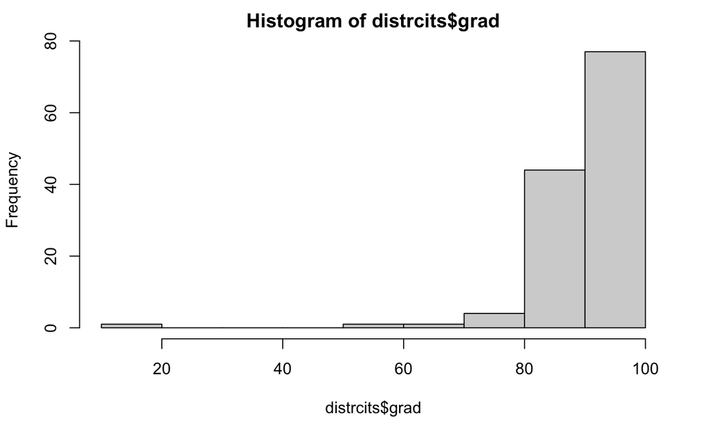

```r
hist(distrcits$grad)
```

##Q9.Create a scatter plot to compare alg_1 proficiency rates to alg_2 rates. What do you notice? Facet this plot by region. Does anything stand out when you facet the plots?

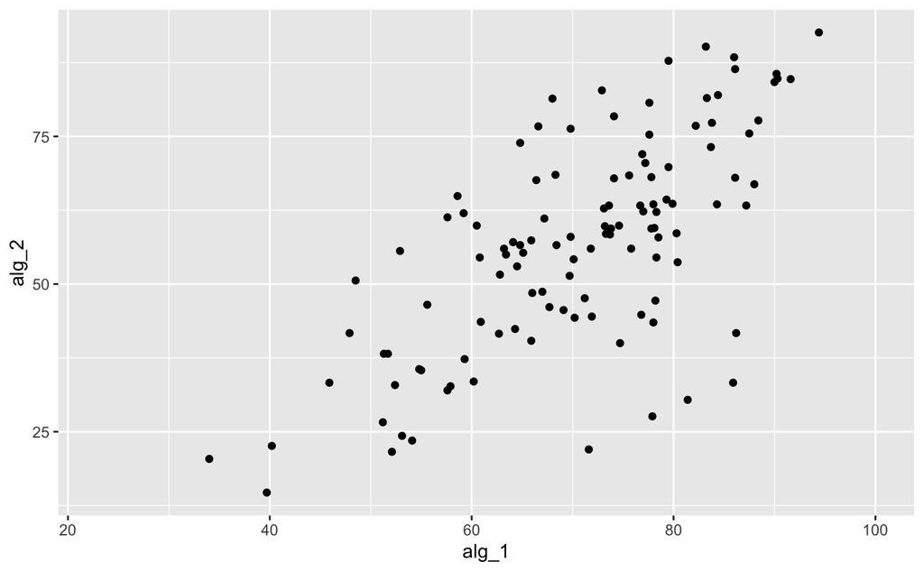

```r
districts %>%
ggplot(aes(x=alg_1, y=alg_2))+
  geom_point()
```

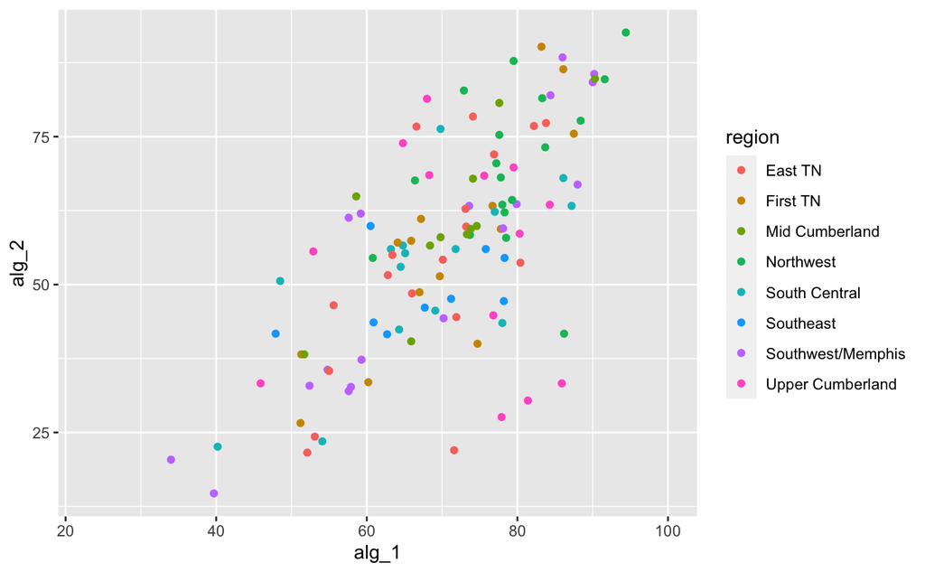

```r
districts %>%
ggplot(aes(x=alg_1, y=alg_2, color= region))+
  geom_point()
```

##Q10. Create a bar chart showing the total enrollment by region. Which region has the highest total enrollment? Which has the smallest? #Mid Cumberland has the hifhest enrollemnt and Northwest has the lowest.

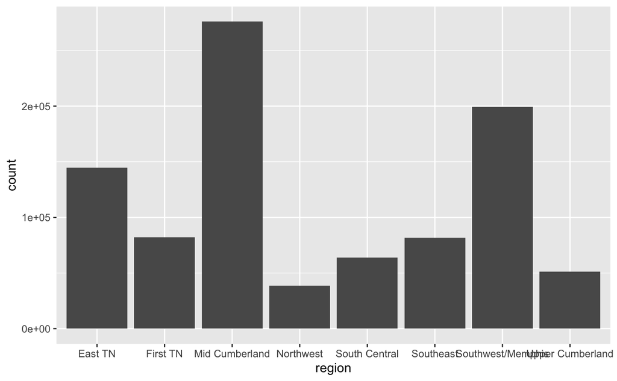

```r
ggplot(districts, aes(region))+
  geom_bar(aes(weight=enrollment))
```

##Q11. When creating this bar chart you may have noticed that some districts have missing enrollment values. For how many districts is this the case? #4 districts have missing values

```r
sapply(districts, function(x) sum(is.na(x)))
```

```
       system   system_name         alg_1         alg_2           bio          chem           ela
            0             0            21            25            17            22             3
        eng_1         eng_2         eng_3          math       science    enrollment         black
           18            18            18             4             2             4             0
     hispanic        native            el           swd            ed  expenditures act_composite
            0             0             0             0             0             4            20
  chronic_abs     suspended      expelled          grad       dropout        region
            1             0             0            17            17             0
```

##Q12.What is the mean graduation rate across all districts? #90.06%

```r
mean(distrcits$grad, na.rm = TRUE)
```

```
[1] 90.06562
```

#What might be wrong with using just the regular mean to assess average graduation rates? #Some districts have a higher graduation rate than the others.

##Q13.Redo the previous question but use a weighted average (weighted.mean) graduation across all districts, weighing by enrollment. How much does this change your answer? Can you explain using the data the reason for the big change from using the mean? #87.28%

```r
enroll_grad <- districts %>%
  select (enrollment, grad) %>%
  na.omit()
  weighted.mean(enroll_grad$grad, enroll_grad$enrollment)
```

```
[1] 87.28671
```

##Q14.Create a boxplot showing enrollment rates per region. Does anything stand out? #Mid Cumberland has the highest enrollment rate.

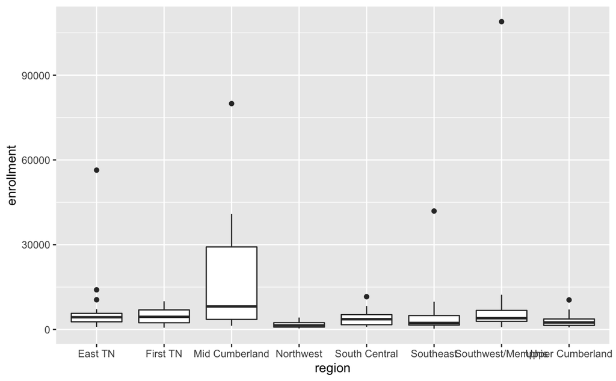

```r
ggplot(districts, aes(x=region, y=enrollment))+
  geom_boxplot()
```

##Q15. Create a boxplot showing graduation rates per region. Does anything stand out?

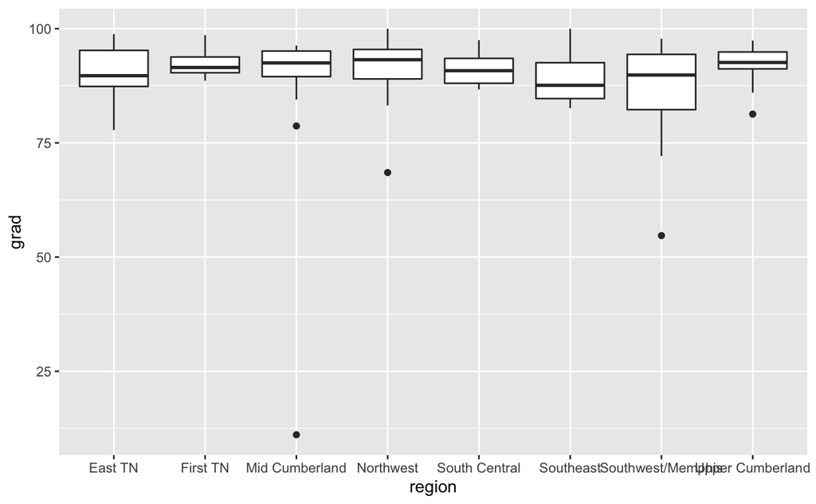

```r
ggplot(districts, aes(x=region, y=grad))+
  geom_boxplot()
```

##Q16. Find the weighted average of graduation rates by region using enrollment as weights. Compare the results you get for the weighted average to what you see from the boxplots. Can you explain any discrepancy?

```r
enroll_grad_region<- districts %>%
  select (grad, enrollment, region) %>%
  na.omit()
  enroll_grad_region %>%
  group_by(region) %>%
  summarise(weighted_grad=weighted.mean(grad, enrollment)) %>%
  arrange(weighted_grad)
```

| region | weighted_grad |
| --- | --- |
| Southwest/Memphis | 79.45971 |
| Southeast | 85.95494 |
| Mid Cumberland | 88.53965 |
| East TN | 89.68801 |
| South Central | 90.47392 |
| Northwest | 91.57705 |
| First TN | 91.91454 |
| Upper Cumberland | 92.24062 |

##Q17. For many districts, values for alg_2 are lower than for alg_1. Create a histogram showing the distribution of differences (alg_1 - alg_2).

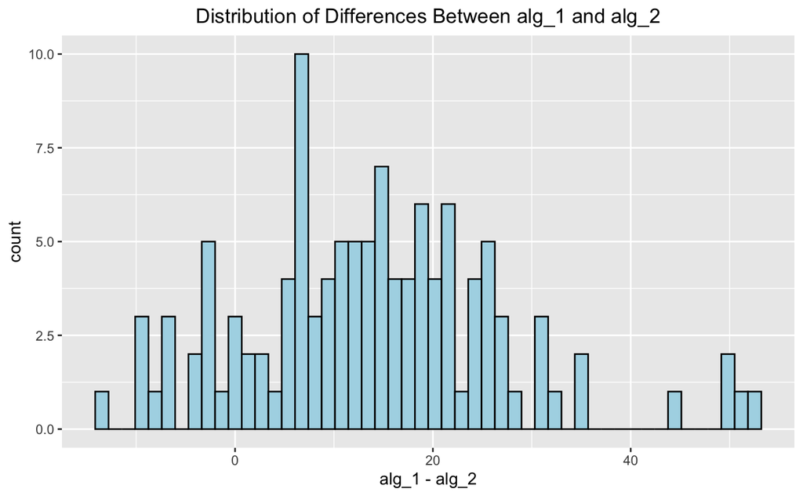

```r
districts %>%
  ggplot(aes(x=alg_1 -alg_2))+
  geom_histogram(fill='light blue', color='black', bins=50)+
  labs(title= 'Distribution of Differences Between alg_1 and alg_2')+
   theme(plot.title = element_text(hjust = 0.5))
```

#Which school had the largest drop from alg_1 to alg_2? #Pickett County

```r
alg1_2 <- districts %>%
  select ('system_name', 'alg_1', 'alg_2') %>%
  na.omit() %>%
  mutate(alg_diff=alg_1-alg_2) %>%
  arrange(alg_diff) %>%
  data.frame()
```

```r
alg1_2
```

| system_name | alg_1 | alg_2 | alg_diff |
| --- | --- | --- | --- |
| Clay County | 68.0 | 81.4 | -13.4 |
| Lenoir City | 66.6 | 76.7 | -10.1 |
| Huntingdon SSD | 72.9 | 82.8 | -9.9 |
| Bledsoe County | 64.8 | 73.9 | -9.1 |
| Union City | 79.5 | 87.8 | -8.3 |
| Greeneville City | 83.2 | 90.2 | -7.0 |
| Coffee County | 69.8 | 76.3 | -6.5 |
| Houston County | 58.6 | 64.9 | -6.3 |
| Oneida SSD | 74.1 | 78.4 | -4.3 |
| Hardin County | 57.6 | 61.3 | -3.7 |

[output cut: 106 more lines]

#For what percentage of schools is it true that alg_2 is larger than alg_1? #in 18 schools (about 12%), it is true that alg_2 is larger than alg_1

```r
districts%>%
  mutate (alg_2>alg_1)
```

[output not shown]

[output cut: 134 more lines]

```r
districts%>%
  filter ( alg_2>alg_1) %>%
  count()
```

| n |
| --- |
| 18 |

```r
districts%>%
  filter ( alg_2>alg_1) %>%
  count()/144 *100
```

| n |
| --- |
| 12.5 |

#Is there a similar dropoff for eng_2 and eng_3? #There is only 1 school in which eng_3 is larger than eng_2

```r
eng2_3<- districts %>%
  select ('system_name', 'eng_2', 'eng_3') %>%
  na.omit() %>%
mutate (eng_diff= eng_3-eng_2) %>%
  arrange (eng_diff) %>%
  data.frame()
```

```r
eng2_3
```

| system_name | eng_2 | eng_3 | eng_diff |
| --- | --- | --- | --- |
| Richard City | 88.5 | 25.0 | -63.5 |
| Dyersburg City | 67.2 | 22.5 | -44.7 |
| Warren County | 60.7 | 17.7 | -43.0 |
| DeKalb County | 72.0 | 31.0 | -41.0 |
| Moore County | 73.0 | 32.4 | -40.6 |
| Sequatchie County | 69.1 | 30.1 | -39.0 |
| Cannon County | 61.2 | 23.8 | -37.4 |
| West Carroll SSD | 67.5 | 30.8 | -36.7 |
| Pickett County | 65.2 | 29.1 | -36.1 |
| Wayne County | 68.9 | 32.9 | -36.0 |

[output cut: 115 more lines]

```r
districts %>%
  filter (eng_3>eng_2) %>%
count()
```

| n |
| --- |
| 1 |

##Q18. You may have noticed that a lot of rows are missing values. Which district has the largest number of missing values? What do you notice about schools that have a lot of missing values?

##Q19. Find the correlation between graduation rate and all other variables. Create a horizontal bar chart showing these correlations. Make sure that your plot is ordered by correlation values. What do you notice from these correlations?

##Q20. Create a scatterplot for `grad` vs. `suspended`. Does what you see make sense given your answer from the previous part?

##Q21. Create a linear regression model using `lm` with target variable `grad` and predictor variable `suspended`. What R^2 value does this model have? What is the interpretation of this number?

##Q22. Add the regression line to your scatterplot using `geom_smooth` with `method='lm'`. How do you feel about the regression line after seeing it plotted on the scatterplot?

**Continued Exploration and Practice**

##Q23. Read in the school-level testing data for 2014, available [here](https://www.tn.gov/content/dam/tn/education/data/data_2014_school_base.xlsx). You might find the readxl library useful for this task. If you use this library, be sure to look at the `na` argument for the `read_excel` function.

##Q24. How many schools have at least 20 percent of students below bsc for Algebra I? Which districts do these schools belong to?

##Q25. How many schools have at least 20 percent of students below bsc for *both* Algebra I and English I?

##Q26. Which grade has the highest pct_adv for Algebra I? Plot the average pct_adv per grade level as a bar chart. Make sure that the bars are ordered by grade level.

##Q27. Find the correlation between pct_adv for Algebra I and pct_adv for Algebra II by school. Create a scatterplot showing Algebra II scores vs. Algebra I scores by school.

##Q28. Find all schools in Rutherford County that have “High School” in their name. For these schools, create a chart (your choice) showing the differences in pct_below_bsc, pct_bsc, pct_prof, and pct_adv for Algebra I when looking across all subgroups and grades.

##Q29. I claim that smaller schools do a better job preparing students for Algebra I standardized tests. Find the average number of valid tests (a proxy for the school size) for schools where the pct_prof_adv for Algebra I is greater than 95. Compare this to the average number of valid tests for all schools. In light of this result, how does my claim look?

##Q30. I also claim that smaller schools do a worse job preparing students for Algebra I standardized tests. Find the average number of valid tests (a proxy for the school size) for schools where the pct_prof_adv for Algebra I is less than 25. Compare this to the average number of valid tests for all schools. In light of this result, how does my claim look now?

##Q31. Create a scatterplot showing pct_prov_adv vs. valid_tests. Can you use this to explain the result for numbers 26 and 27?

If you finish all of the above questions, continue to explore the two datasets and see what else interesting you can find.

Also, check out the plotly library for R. The `ggplotly` function makes it very easy to convert ggplot plots into interactive plotly plots.